# Analysis

Ruipeng Wei

Case Western Reserve University  
ruipeng.wei@outlook.com

2022-04-13

Abstract

2022 Shanghai covid19 date analysis.

```r
knitr::opts_chunk$set(echo = TRUE)
knitr::opts_chunk$set(warning = FALSE)
knitr::opts_knit$set(root.dir = '~/Desktop/')
```

# library

```r
library(readxl)
library(ggplot2)
library(scales)
library(minpack.lm)
library(ggpubr)
```

# read in data

```r
sh = read_excel("2022SH_covid19.xlsx")
sh$positive = as.numeric(sh$positive)
sh$total = as.numeric(sh$total)
sh$`Asymptomatic infections` = as.numeric(sh$`Asymptomatic infections`)
sh$`pos/total` = as.numeric(sh$`pos/total`)
```

All data captured from Shanghai gov website （http://wsjkw.sh.gov.cn/yqtb/index.html）. 所有数据均来自于上海市卫生健康委员会网站：http://wsjkw.sh.gov.cn/yqtb/index.html。

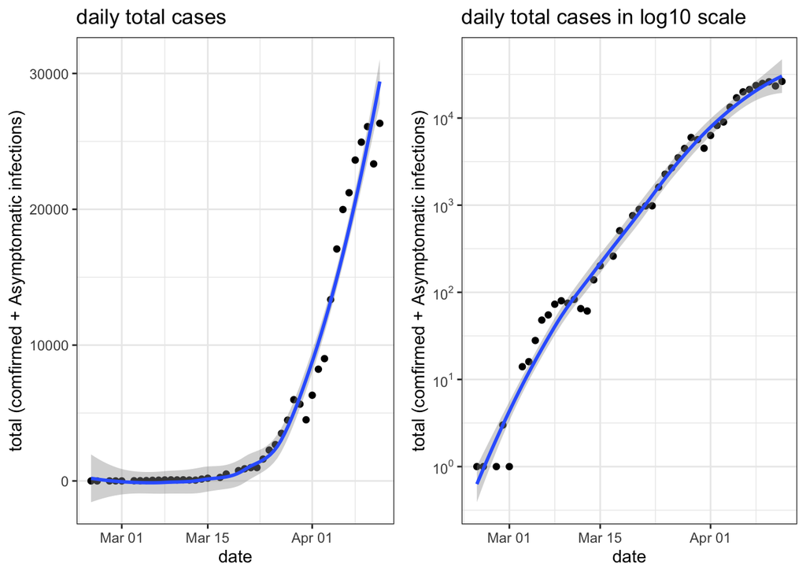

```r
p1 = ggplot(data=sh,aes(x=date,y=total)) +
  geom_point() +
  geom_smooth() +
  theme_bw() +
  ggtitle("daily total cases") +
  ylab("total (comfirmed + Asymptomatic infections)")

p2 = ggplot(data=sh,aes(x=date,y=total)) +
  geom_point() +
  geom_smooth() +
  theme_bw() +
  scale_y_continuous(trans = log10_trans(),
    breaks = trans_breaks("log10", function(x) 10^x),
    labels = trans_format("log10", math_format(10^.x))) +
  ggtitle("daily total cases in log10 scale") +
  ylab("total (comfirmed + Asymptomatic infections)")

ggarrange(p1, p2 ,
          #labels = c("Shanghai daily reported positive cases since Feb 24th", "Shanghai daily reported positive cases since Feb 24th in log10 scale"),
          ncol = 2)
```

Shanghai daily cases plots, left panel in usual y axis, right panel in log10 scale y axis. Blue line is ggplot automatically generated smooth trend lines, grey is 95% confident interval.

上图为上海市每日新增人数（为确诊和阳性无症状人数之和），左图为正常坐标，右图为将新增人数进行log10转换后得到。 蓝线为绘图包自动拟合的趋势线，灰色为95%置信区间。

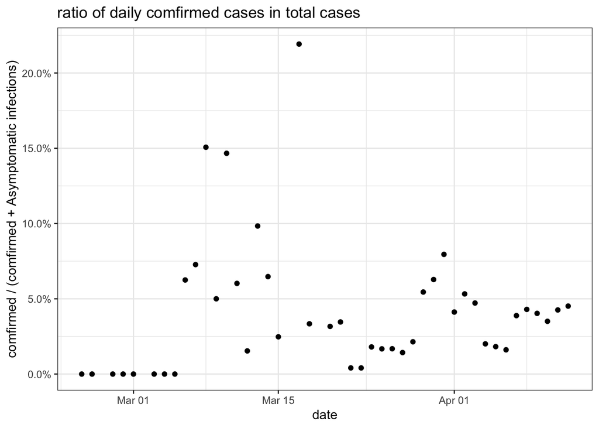

```r
ggplot(data=sh,aes(x=date,y=`pos/total`)) +
  geom_point() +
  theme_bw() +
  scale_y_continuous(labels = scales::percent) +
  ylab("comfirmed / (comfirmed + Asymptomatic infections)") +
  ggtitle("ratio of daily comfirmed cases in total cases")
```

Plot of ration of daily comfirmed cases to total cases (comfirmed + asymptomatic infections). Y axis in percentage.

每日确诊人数占总数（确诊+阳性无症状）的百分比图。

## fit exp

```r
sh$num_date = as.numeric(sh$date) - as.numeric(sh$date)[1]
sh = as.data.frame(sh)
sh$num_date = sh$num_date/(24*3600)
```

```r
sh_exp <- nls(data=sh[10:44,], total ~ a*exp(b*num_date) + c,
               start = list(a = 0.5, b = 0.2,c=0.1))
```

```r
#sh_exp_predict = cbind.data.frame(c(0:32)+10,as.data.frame(predict(sh_exp,x=c(0,50))))

sh_exp_predict <- cbind.data.frame(10:50,coef(sh_exp)[1]*exp(coef(sh_exp)[2]*10:50)+coef(sh_exp)[3])
colnames(sh_exp_predict) = c("date","pre")
```

##fit logistic Using daily total cases (from March 6th) to fit a logistic increase model. 用从3月6日开始的每日确诊总数进行一个logistic函数的拟合。

```r
sh_log <- nls(total ~ SSlogis(num_date, Asym, xmid, scal), data = sh[10:44,])
```

```r
#sh_log_predict = cbind.data.frame(c(0:32)+10,as.data.frame(predict(sh_log,x=c(0,50))))

sh_log_predict <- cbind.data.frame(10:50,coef(sh_log)[1]/(1+exp((coef(sh_log)[2]- c(10:50))/coef(sh_log)[3])))

colnames(sh_log_predict) = c("date","pre")
```

# plot fitting results

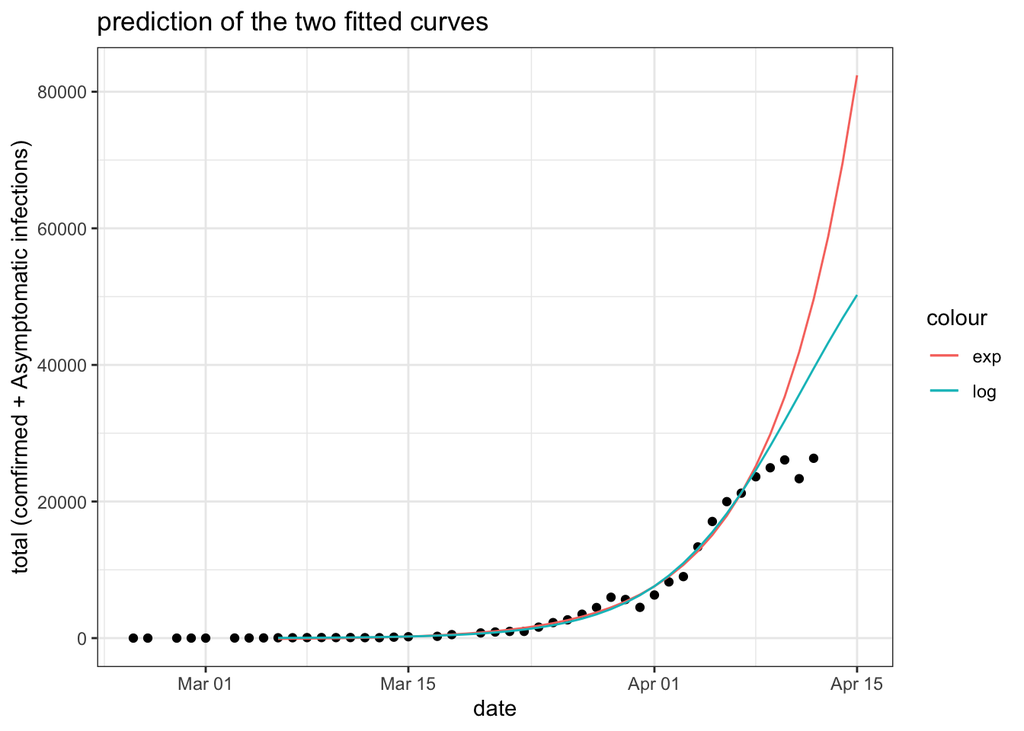

```r
Sys.setenv(TZ='UTC')
sh_exp_predict$realdate = as.Date(sh_exp_predict$date, origin = "2022-02-24 UTC")
sh_exp_predict$realdate = as.POSIXct(sh_exp_predict$realdate)
sh_log_predict$realdate = as.Date(sh_log_predict$date, origin = "2022-02-24 UTC")
sh_log_predict$realdate = as.POSIXct(sh_log_predict$realdate)

ggplot(data=sh,aes(x=date,y=total)) +
  geom_point() +
  geom_line(data=sh_exp_predict,aes(x=realdate,y=pre,col="exp")) +
  geom_line(data=sh_log_predict,aes(x=realdate,y=pre,col="log")) +
  theme_bw() +
  xlab("date") +
  ylab("total (comfirmed + Asymptomatic infections)") +
  ggtitle("prediction of the two fitted curves")
```

Black dots represent real reported data, red line represents exponential increase equation fitted curve, cyan line represents logistic growth fitted curve.

黑色的点表示实际获取的数据，红色的线表示指数上升模型的趋势，青色的线表示logistic模型的趋势。